# 有向無環圖

Steven

2024/09/05, 09/19, 9/26

## 1. 有向無環圖 (Directed Acyclic Graph, DAG)

- 這次分享基本上取自 Scott Cunningham - Causal Inference_ The Mixtape (2021) 第 3 章
- 圖形因果建模的歷史可以追溯到 20 世紀初的 Sewall Wright, 他是現代遺傳學之父之一，也是經濟學家 Philip Wright 的兒子。
- Sewall 開發了遺傳學路徑圖，而 Philip 則將其應用於計量經濟學識別。然而，經濟學界（與統計學界） 基本上無視了圖形建模在因果推理中的應用。
- 透過電腦科學家、圖靈獎得主 Judea Pearl 的努力，圖形推理在因果推理方面才復興。
  - 他在 Judea Pearl - Causality (2009, 2nd ed.) 中解釋了這一點，本書是因果推理的一般理論，闡述了有向圖的用途。
- 圖形模型對設計可靠的**識別** (identification) 策略大有幫助。

### 1-1. 補充: 何謂「識別」？

- 在統計學和計量經濟學中，識別指的是模型的結構參數能夠被唯一且明確地估計出來的條件。
- 具體而言，識別意味著觀察到的數據提供了足夠的資訊，從而使模型中的未知參數能夠被唯一確定。
- 識別問題的三種類型:
  - 完全識別 (Exactly Identified):  
    當數據中提供的資訊（觀測方程的數量）等於模型中未知參數的數量時，模型是完全識別的。此時參數可以唯一確定。
  - 過度識別 (Over-Identified):  
    當數據提供的資訊多於未知參數的數量時，模型是過度識別的。*這通常被視為有利的情況*，因為我們可以檢驗模型的適配度，並確保參數估計的一致性。
  - 未識別 (Under-Identified):  
    當數據提供的資訊少於模型中未知參數的數量時，模型是未識別的。此時，無法唯一確定參數，因為不同的參數組合可能會導致相同的觀察結果。
- 識別的重要性:  
  識別是統計建模中的一個核心問題，因為如果模型未識別，無法確定我們所估計的參數是否有意義或能夠反映真實的現象。

### 1-2. 符號說明

- **我們將 DAG 視為因果效應鏈的圖形表示**:  
  因果效應本身基於一些潛在的、無法觀察到的結構化過程，所有這些都可以用節點和箭頭等圖形符號表示出來。
  - 節點代表隨機變數，而這些隨機變數假定是由某個資料生成過程 (data generating process) 產生的。
  - 箭頭代表兩個隨機變數之間的因果效應，箭頭的方向反映了因果關係的方向。
- 在 DAG 中，因果關係是單向的。具體而言，它在時間上是向前的。DAG 中沒有迴圈 (cycle)。
  - 要顯示反向因果關係，需要創建多個節點，很可能是同一節點的兩個版本，以時間索引 (time index) 區隔。
  - 同樣，供需模型中的同時性也不能直接用 DAG 來表示，建議採用不同的方法。
- DAG 用反事實來解釋因果關係，**因果效應被定義為世界兩種狀態之間的比較**:  
  一種狀態是當某種干預取某些值（實際發生的值），另一種狀態是在干預取其他值（反事實）。
- 因果效應有兩種方式:
  - 直接影響，例如: $D \to Y$
  - 由第三個變數中介 (mediate): $D \to X \to Y$
- DAG 意在描述與 $D$ 對 $Y$ 的影響相關的所有因果關係:  
  既明確描述了因果效應路徑，而*缺少箭頭*表示*缺少因果路徑*。 因此，**DAG 既包含連接變數的箭頭，也包含排除哪些箭頭**。
- 一個完整的 DAG 將包含圖中變數之間的所有直接因果效應，以及圖中任何一對變數的所有共同原因。

### 1-3. 補充: DAG 從何而來？

- 經驗、信念、探索性分析、因果發現…
- DAG 是最新知識的理論表示。這些知識來自於各種不同的來源。例如：科學模型、與專家的對話、自己的觀察和經驗、文獻綜述，以及您自己的直覺和假設。

### 1-4. DAG 的積極意義

- DAG 對於理解先驗知識在確定因果效應中的關鍵作用非常有用。
- DAG 對於交流研究設計和估計方法非常有幫助。
  - 工具變數 (instrument variable) 尤其如此，因為工具變數有非常直觀的 DAG 表示。
  - 透過後門準則 (backdoor criterion) 和對撞 (colliding) 等概念，設計良好的 DAG 可以協助發展出可靠的研究設計，以確定某些干預措施的因果效應。
- DAG 讓我們明白了一個道理：**所有因果效應的識別都需要假設**。

## 3. DAG 的正式介紹

### 3-1. 簡單的 DAG

#### 3-1-1. 可觀測的干擾因子 $X$

- 在底下的 DAG 中我們有三個隨機變數: $D, X, Y$.

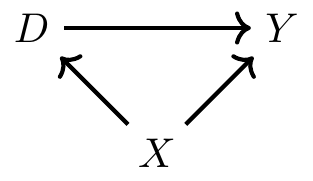

- 第一條*直接*路徑從 $D$ 到 $Y$:  
  $D \to Y$，這是因果路徑。
- 第二條路徑連接 $D$ 與 $Y$:  
  $D \leftarrow X \to Y$， 稱為後門路徑 (backdoor pathway)。後門路徑*不是* $D$ 與 $Y$ 之間的因果關係。
- 後門路徑的想法是我們可以從 DAG 中學到的最重要的東西之一。
  - 它等同於遺漏變數偏差，因為$X$同時影響結果（此指$Y$）和處理變數（treatment variable，此指$D$）。
- 在迴歸中不控制變數會導致遺漏變數偏差一樣，讓後門打開也會產生偏差。
- 我們稱 $X$ 為干擾因素 (condounding factor, confounder)，因此它干擾了我們評估 $D$ 對 $Y$ 效果的能力。

#### 3-1-2. 無法觀測的干擾因子 $U$

- 在底下的 DAG 中我們有三個隨機變數: $D, U, Y$.

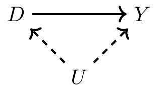

#### 3-1-3. 對撞因子

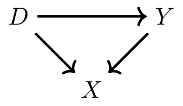

### 3-2. 應用例子

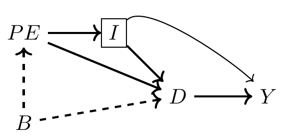

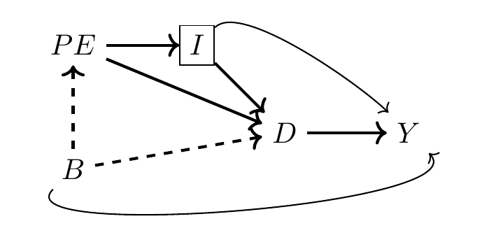

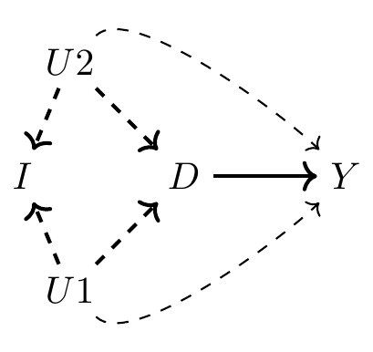

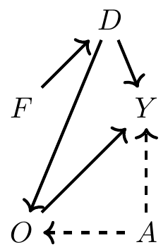